# Taller_4

Estadística descriptiva

Zuleima carriazo

Septiembre 5 de 2020

# Datos actualizados.

## Analisís de los resultados de la pregunta 1

La siguiete grafica muestra la frecuencia de las dos opcione unicas de repuestas,y en ella podemos notar que la mayoria de estudiantes hizo el deber de ver el episodio solicitado por el profesor.

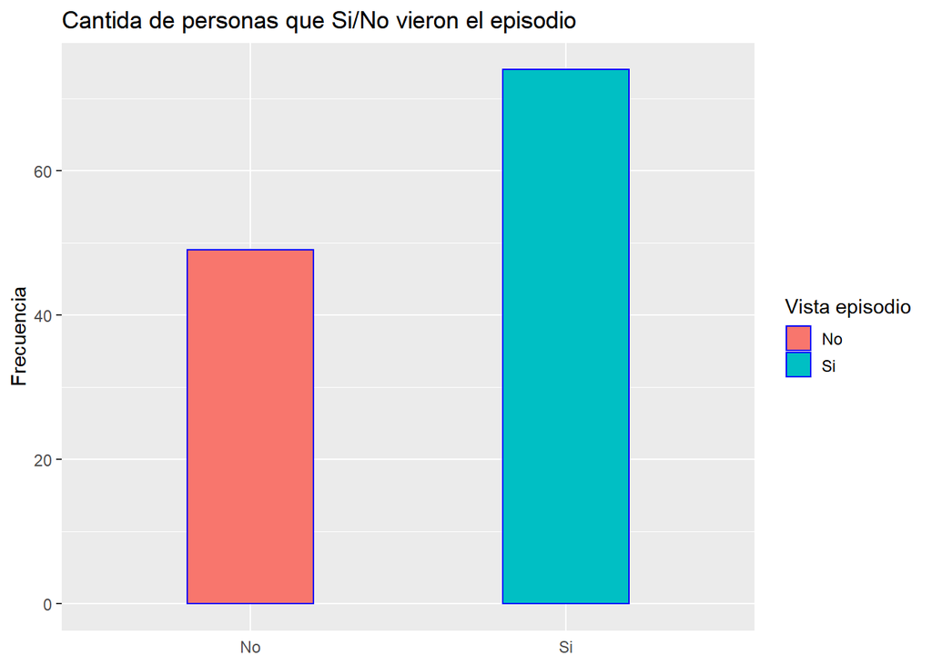

La información presentada en la anterior gráfica, tambíen la podemos visualizar en la siguiente tabla.

| ¿vió episodio? | Frecuencia | Porcentaje |
| --- | --- | --- |
| No | 49 | 39.84 |
| Si | 74 | 60.16 |

## Analisís de los resultados de la segunda pregunta.

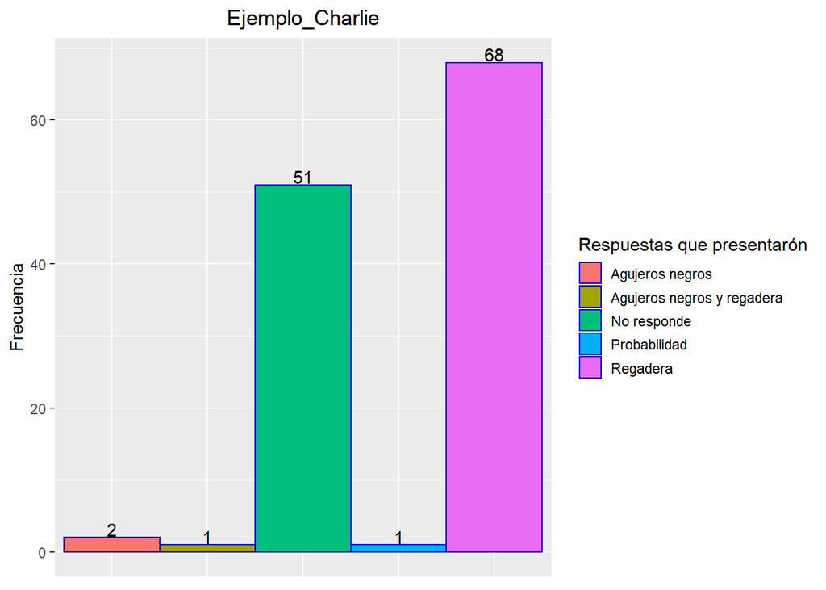

La información presentada en la anterior gráfica, tambíen la podemos visualizar en la siguiete tabla.

| Respuestas que presentarón | Frecuencia |
| --- | --- |
| No responde | 51 |
| Regadera | 68 |
| Probabilidad | 1 |
| Agujeros negros y regadera | 1 |
| Agujeros negros | 2 |

## Analisís de los resultados de la tercera pregunta.

En la siguinte gráfica podemos notar el analisís relacionado con las excusas que presentaron los estudiantes al no ver el primer episodio de la serie numbers, en ella podemos notar la amplitud de estas mismas, y la que mas coincide la mayoria de los estudiantes.

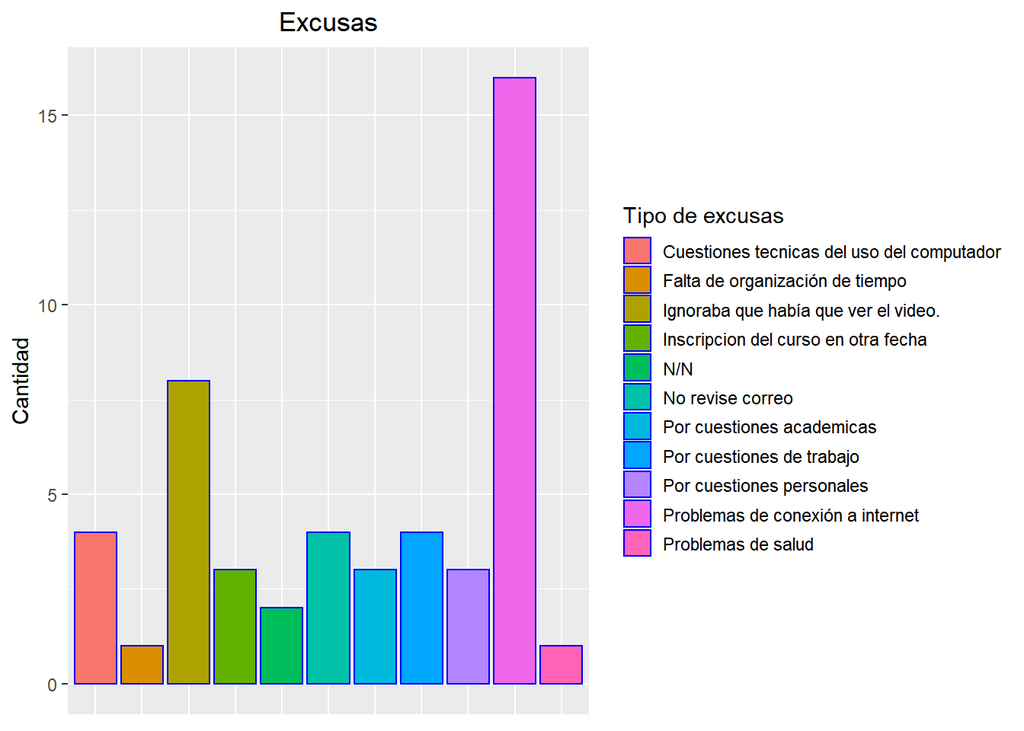

La informacion que nos presentó la gráfica anterior, tambíen la podemos visualizar en la siguiente tabla.

| Tipo de excusas que dieron los estudiantes. | Frecuencia |
| --- | --- |
| Cuestiones tecnicas del uso del computador | 4 |
| Falta de organización de tiempo | 1 |
| Ignoraba que había que ver el video. | 8 |
| Inscripcion del curso en otra fecha | 3 |
| N/N | 2 |
| No revise correo | 4 |
| Por cuestiones academicas | 3 |
| Por cuestiones de trabajo | 4 |
| Por cuestiones personales | 3 |
| Problemas de conexión a internet | 16 |
| Problemas de salud | 1 |

## Analisís de la tercera pregunta, de las otras excusas.

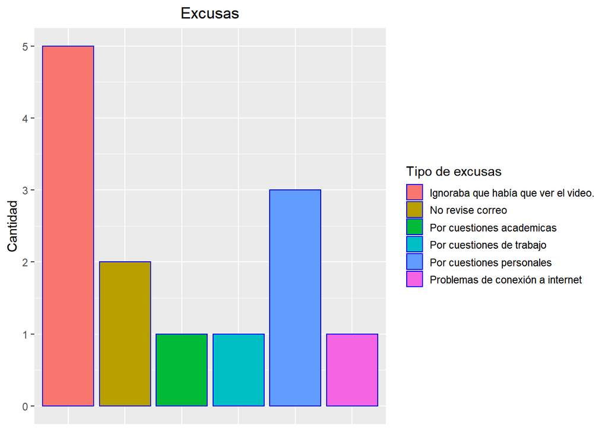

La información que esta representada en la grafica anterior, tambíen la podemos ver el la siguiente gráfica.

| Tipo de excusas que dieron los estudiantes. | Frecuencia |
| --- | --- |
| Ignoraba que había que ver el video. | 5 |
| No revise correo | 2 |
| Por cuestiones academicas | 1 |
| Por cuestiones de trabajo | 1 |
| Por cuestiones personales | 3 |
| Problemas de conexión a internet | 1 |

## Depuración de datos de la cuarta pregunta.

En esta ocasión no se reprento la información detallada en una gráfica, porque se consideró que se representa mejor esta información en una tabla. Simplemente se dividiero las opiniones entre la mudanza del asesino y fallas matemáticas de charlie.

| Pregunta Charlie depurada | Frecuencia |
| --- | --- |
| A traves de las matematicas generar una ecuacion para lograr su ubicación | 41 |
| Encontrar una zona de vivienda o de concurrencia del asesino | 31 |
| N/N | 1 |
| NA | 50 |

## Analisís de la quita pregunta.

El dato mas resaltante es la concidencia que tuvimos al elegir los agujeros negros como ejemplo de la tecnicas de charlie para atrapara el asesino.

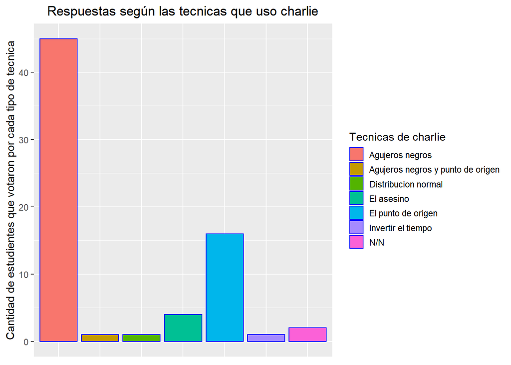

En la siguiente tabla se puede visualizar la información que se presentó en la gráfica anterior.

| Opciones de tecnicas de las que uso charlie | Cantida por cada una |
| --- | --- |
| Agujeros negros | 45 |
| Agujeros negros y punto de origen | 1 |
| Distribucion normal | 1 |
| El asesino | 4 |
| El punto de origen | 16 |
| Invertir el tiempo | 1 |
| N/N | 2 |

## Analisis de la pregunta sesta.

Aquí podemos notar la variedad de opiniones que tuvimos al responder el porque no se encontro el asesino el la primera ocasion que se le busco, como se puede ver en la siguiente gráfica.

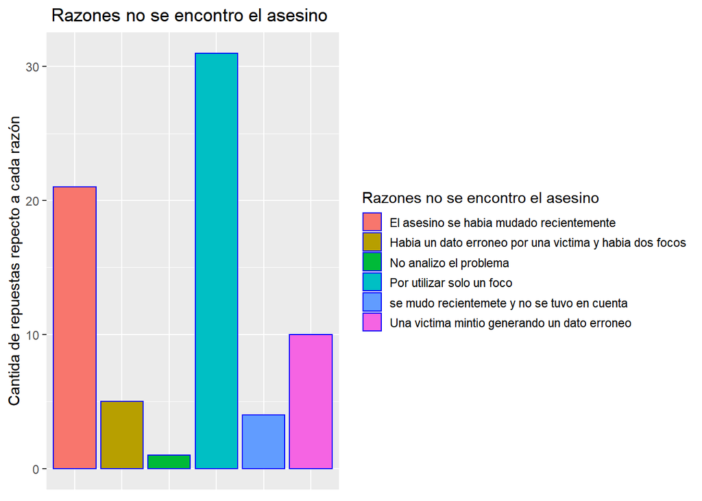

En la tabla que se presenta a continuación se puede ver la informacion que está representando la gráfica aterior.

| Razon por la que no encontro el asesino por primera ves | Frecuencia de las opciones de cada opcion de repuesta |
| --- | --- |
| El asesino se habia mudado recientemente | 21 |
| se mudo recientemete y no se tuvo en cuenta | 4 |
| Habia un dato erroneo por una victima y habia dos focos | 5 |
| No analizo el problema | 1 |
| Por utilizar solo un foco | 31 |
| Una victima mintio generando un dato erroneo | 10 |

## Analisis de la septima pregunta.

La minoria de los estudiantes al ver el primer episodio de la serie numbers no detalló en la cuentas que sacó charlie para darle el año exacto en que se podria ganar la lotería y esto se puede visualizar en la siguinte gráfica.

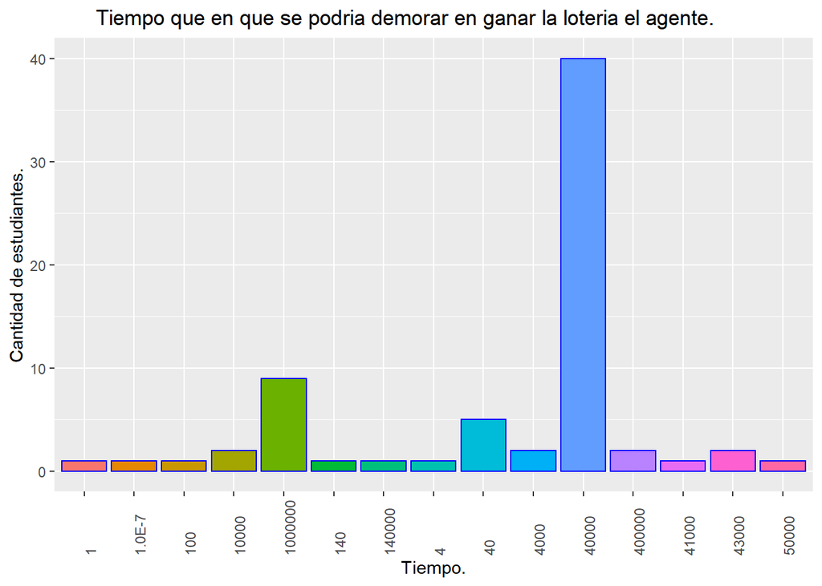

## Conclusión.

Al ver el primer episodio de la serie numbers,mis compañeros y yo tuvimos desaciertos validos que se reflejan en la graficas y tablas, tuvimos tambíen respuestas redactadas de modo diferente, pero que sematicamente concluyen una misma cosa. Se hicieron depuraciones de estas mismas, y se agregaron componentes visulaes para evidenciar lo planteado en detalle.

## Recomendaciones.

No tengo recomendaciones que dar, estoy de acuerdo con todo.